# HousePriceDataAnalysis

##### Sumario Cluster 3

Gracias al sumario podemos conocer que las observaciones que se agruparon en este clúster tienen las siguientes características: - Tienen un precio promedio de U$D 407386. - Tienen un tamaño promedio de 1680 sqft. - Tienen baños con tamaño 1.75 sqft - Tienen habitaciones con 3 sqft. - Tienen grado 7.

```r
sumario_cluster_raw_3_kmean5 <- summary(cluster_3_raw_kmean5)
sumario_cluster_raw_3_kmean5
```

```
     price          sqft_living   bathrooms_0.5 bathrooms_0.75
 Min.   : 107000   Min.   : 290   Min.   :0     Min.   :0.0000000
 1st Qu.: 280000   1st Qu.:1360   1st Qu.:0     1st Qu.:0.0000000
 Median : 379900   Median :1630   Median :0     Median :0.0000000
 Mean   : 407386   Mean   :1680   Mean   :0     Mean   :0.0004839
 3rd Qu.: 499000   3rd Qu.:1940   3rd Qu.:0     3rd Qu.:0.0000000
  bathrooms_1     bathrooms_1.25      bathrooms_1.5    bathrooms_1.75
 Min.   :0.0000   Min.   :0.0000000   Min.   :0.0000   Min.   :0.0000
 1st Qu.:0.0000   1st Qu.:0.0000000   1st Qu.:0.0000   1st Qu.:0.0000
 Median :0.0000   Median :0.0000000   Median :0.0000   Median :0.0000
 Mean   :0.1631   Mean   :0.0004839   Mean   :0.1484   Mean   :0.2977
 3rd Qu.:0.0000   3rd Qu.:0.0000000   3rd Qu.:0.0000   3rd Qu.:1.0000
  bathrooms_2    bathrooms_2.25    bathrooms_2.5    bathrooms_2.75
 Min.   :0.000   Min.   :0.00000   Min.   :0.0000   Min.   :0
 1st Qu.:0.000   1st Qu.:0.00000   1st Qu.:0.0000   1st Qu.:0
 Median :0.000   Median :0.00000   Median :0.0000   Median :0
 Mean   :0.165   Mean   :0.09217   Mean   :0.1094   Mean   :0
 3rd Qu.:0.000   3rd Qu.:0.00000   3rd Qu.:0.0000   3rd Qu.:0
  bathrooms_3      bathrooms_3.25     bathrooms_3.5      bathrooms_3.75
 Min.   :0.00000   Min.   :0.000000   Min.   :0.000000   Min.   :0.0000000
 1st Qu.:0.00000   1st Qu.:0.000000   1st Qu.:0.000000   1st Qu.:0.0000000
 Median :0.00000   Median :0.000000   Median :0.000000   Median :0.0000000
 Mean   :0.01657   Mean   :0.002661   Mean   :0.002419   Mean   :0.0009677
 3rd Qu.:0.00000   3rd Qu.:0.000000   3rd Qu.:0.000000   3rd Qu.:0.0000000
  bathrooms_4        bathrooms_4.25     bathrooms_4.5 bathrooms_4.75  bathrooms_5
 Min.   :0.0000000   Min.   :0.000000   Min.   :0     Min.   :0      Min.   :0
 1st Qu.:0.0000000   1st Qu.:0.000000   1st Qu.:0     1st Qu.:0      1st Qu.:0
 Median :0.0000000   Median :0.000000   Median :0     Median :0      Median :0
 Mean   :0.0002419   Mean   :0.000121   Mean   :0     Mean   :0      Mean   :0
 3rd Qu.:0.0000000   3rd Qu.:0.000000   3rd Qu.:0     3rd Qu.:0      3rd Qu.:0
 bathrooms_5.25 bathrooms_5.5 bathrooms_5.75  bathrooms_6 bathrooms_6.25
 Min.   :0      Min.   :0     Min.   :0      Min.   :0    Min.   :0
 1st Qu.:0      1st Qu.:0     1st Qu.:0      1st Qu.:0    1st Qu.:0
 Median :0      Median :0     Median :0      Median :0    Median :0
 Mean   :0      Mean   :0     Mean   :0      Mean   :0    Mean   :0
 3rd Qu.:0      3rd Qu.:0     3rd Qu.:0      3rd Qu.:0    3rd Qu.:0
 bathrooms_6.5 bathrooms_6.75 bathrooms_7.5 bathrooms_7.75  bathrooms_8
 Min.   :0     Min.   :0      Min.   :0     Min.   :0      Min.   :0
 1st Qu.:0     1st Qu.:0      1st Qu.:0     1st Qu.:0      1st Qu.:0
 Median :0     Median :0      Median :0     Median :0      Median :0
```

[output cut: 204 more lines]

```
 Mean   :0.183   Mean   :0.04343   Mean   :0.008951   Mean   :0.0008467
 3rd Qu.:0.000   3rd Qu.:0.00000   3rd Qu.:0.000000   3rd Qu.:0.0000000
   bedrooms_8          bedrooms_9         bedrooms_10         bedrooms_11
 Min.   :0.0000000   Min.   :0.0000000   Min.   :0.0000000   Min.   :0.000000
 1st Qu.:0.0000000   1st Qu.:0.0000000   1st Qu.:0.0000000   1st Qu.:0.000000
 Median :0.0000000   Median :0.0000000   Median :0.0000000   Median :0.000000
 Mean   :0.0003629   Mean   :0.0002419   Mean   :0.0002419   Mean   :0.000121
 3rd Qu.:0.0000000   3rd Qu.:0.0000000   3rd Qu.:0.0000000   3rd Qu.:0.000000
  bedrooms_33
 Min.   :0.000000
 1st Qu.:0.000000
 Median :0.000000
 Mean   :0.000121
 3rd Qu.:0.000000
 [ reached getOption("max.print") -- omitted 1 row ]
```

##### Cluster 4

```r
cluster_4_raw_kmean5 <- dataset_cluster_raw_5
cluster_4_raw_kmean5 <- filter(cluster_4_raw_kmean5,cluster==4)
cluster_4_raw_kmean5$cluster=NULL
```

##### Sumario Cluster 4

Gracias al sumario podemos conocer que las observaciones que se agruparon en este clúster tienen las siguientes características: - Tienen un precio promedio de U$D 629668. - Tienen un tamaño promedio de 2510 sqft. - Tienen habitaciones con 4 o 5 sqft. - Tienen grado 11.

```r
sumario_cluster_raw_4_kmean5 <- summary(cluster_4_raw_kmean5)
sumario_cluster_raw_4_kmean5
```

```
     price          sqft_living   bathrooms_0.5       bathrooms_0.75
 Min.   : 175000   Min.   : 750   Min.   :0.0000000   Min.   :0
 1st Qu.: 425000   1st Qu.:2010   1st Qu.:0.0000000   1st Qu.:0
 Median : 570000   Median :2432   Median :0.0000000   Median :0
 Mean   : 629668   Mean   :2510   Mean   :0.0001239   Mean   :0
 3rd Qu.: 760000   3rd Qu.:2960   3rd Qu.:0.0000000   3rd Qu.:0
  bathrooms_1       bathrooms_1.25      bathrooms_1.5     bathrooms_1.75
 Min.   :0.000000   Min.   :0.0000000   Min.   :0.00000   Min.   :0.00000
 1st Qu.:0.000000   1st Qu.:0.0000000   1st Qu.:0.00000   1st Qu.:0.00000
 Median :0.000000   Median :0.0000000   Median :0.00000   Median :0.00000
 Mean   :0.003344   Mean   :0.0003716   Mean   :0.01598   Mean   :0.04608
 3rd Qu.:0.000000   3rd Qu.:0.0000000   3rd Qu.:0.00000   3rd Qu.:0.00000
  bathrooms_2      bathrooms_2.25   bathrooms_2.5    bathrooms_2.75
 Min.   :0.00000   Min.   :0.0000   Min.   :0.0000   Min.   :0
 1st Qu.:0.00000   1st Qu.:0.0000   1st Qu.:0.0000   1st Qu.:0
 Median :0.00000   Median :0.0000   Median :1.0000   Median :0
 Mean   :0.04534   Mean   :0.1545   Mean   :0.5248   Mean   :0
 3rd Qu.:0.00000   3rd Qu.:0.0000   3rd Qu.:1.0000   3rd Qu.:0
  bathrooms_3      bathrooms_3.25   bathrooms_3.5     bathrooms_3.75
 Min.   :0.00000   Min.   :0.0000   Min.   :0.00000   Min.   :0.000000
 1st Qu.:0.00000   1st Qu.:0.0000   1st Qu.:0.00000   1st Qu.:0.000000
 Median :0.00000   Median :0.0000   Median :0.00000   Median :0.000000
 Mean   :0.07061   Mean   :0.0571   Mean   :0.07147   Mean   :0.009786
 3rd Qu.:0.00000   3rd Qu.:0.0000   3rd Qu.:0.00000   3rd Qu.:0.000000
  bathrooms_4        bathrooms_4.25 bathrooms_4.5 bathrooms_4.75  bathrooms_5
 Min.   :0.0000000   Min.   :0      Min.   :0     Min.   :0      Min.   :0
 1st Qu.:0.0000000   1st Qu.:0      1st Qu.:0     1st Qu.:0      1st Qu.:0
 Median :0.0000000   Median :0      Median :0     Median :0      Median :0
 Mean   :0.0001239   Mean   :0      Mean   :0     Mean   :0      Mean   :0
 3rd Qu.:0.0000000   3rd Qu.:0      3rd Qu.:0     3rd Qu.:0      3rd Qu.:0
 bathrooms_5.25 bathrooms_5.5 bathrooms_5.75  bathrooms_6 bathrooms_6.25
 Min.   :0      Min.   :0     Min.   :0      Min.   :0    Min.   :0
 1st Qu.:0      1st Qu.:0     1st Qu.:0      1st Qu.:0    1st Qu.:0
 Median :0      Median :0     Median :0      Median :0    Median :0
 Mean   :0      Mean   :0     Mean   :0      Mean   :0    Mean   :0
 3rd Qu.:0      3rd Qu.:0     3rd Qu.:0      3rd Qu.:0    3rd Qu.:0
 bathrooms_6.5 bathrooms_6.75 bathrooms_7.5 bathrooms_7.75  bathrooms_8
 Min.   :0     Min.   :0      Min.   :0     Min.   :0      Min.   :0
 1st Qu.:0     1st Qu.:0      1st Qu.:0     1st Qu.:0      1st Qu.:0
 Median :0     Median :0      Median :0     Median :0      Median :0
```

[output cut: 198 more lines]

```
 Mean   :0.000991   Mean   :0.05611   Mean   :0.3406   Mean   :0.496
 3rd Qu.:0.000000   3rd Qu.:0.00000   3rd Qu.:1.0000   3rd Qu.:1.000
   bedrooms_5        bedrooms_6        bedrooms_7         bedrooms_8
 Min.   :0.00000   Min.   :0.00000   Min.   :0.000000   Min.   :0.0000000
 1st Qu.:0.00000   1st Qu.:0.00000   1st Qu.:0.000000   1st Qu.:0.0000000
 Median :0.00000   Median :0.00000   Median :0.000000   Median :0.0000000
 Mean   :0.09315   Mean   :0.01152   Mean   :0.000991   Mean   :0.0001239
 3rd Qu.:0.00000   3rd Qu.:0.00000   3rd Qu.:0.000000   3rd Qu.:0.0000000
   bedrooms_9  bedrooms_10  bedrooms_11  bedrooms_33
 Min.   :0    Min.   :0    Min.   :0    Min.   :0
 1st Qu.:0    1st Qu.:0    1st Qu.:0    1st Qu.:0
 Median :0    Median :0    Median :0    Median :0
 Mean   :0    Mean   :0    Mean   :0    Mean   :0
 3rd Qu.:0    3rd Qu.:0    3rd Qu.:0    3rd Qu.:0
 [ reached getOption("max.print") -- omitted 1 row ]
```

##### Cluster 5

```r
cluster_5_raw_kmean5 <- dataset_cluster_raw_5
cluster_5_raw_kmean5 <- filter(cluster_5_raw_kmean5,cluster==5)
cluster_5_raw_kmean5$cluster=NULL
```

##### Sumario Cluster 5

```r
sumario_cluster_raw_5_kmean5 <- summary(cluster_5_raw_kmean5)
sumario_cluster_raw_5_kmean5
```

```
     price          sqft_living   bathrooms_0.5       bathrooms_0.75
 Min.   :  75000   Min.   : 370   Min.   :0.0000000   Min.   :0.00000
 1st Qu.: 225000   1st Qu.: 880   1st Qu.:0.0000000   1st Qu.:0.00000
 Median : 305000   Median :1070   Median :0.0000000   Median :0.00000
 Mean   : 331176   Mean   :1140   Mean   :0.0009944   Mean   :0.02221
 3rd Qu.: 414000   3rd Qu.:1330   3rd Qu.:0.0000000   3rd Qu.:0.00000
  bathrooms_1     bathrooms_1.25 bathrooms_1.5     bathrooms_1.75
 Min.   :0.0000   Min.   :0      Min.   :0.00000   Min.   :0.00000
 1st Qu.:1.0000   1st Qu.:0      1st Qu.:0.00000   1st Qu.:0.00000
 Median :1.0000   Median :0      Median :0.00000   Median :0.00000
 Mean   :0.8197   Mean   :0      Mean   :0.02884   Mean   :0.06198
 3rd Qu.:1.0000   3rd Qu.:0      3rd Qu.:0.00000   3rd Qu.:0.00000
  bathrooms_2      bathrooms_2.25      bathrooms_2.5      bathrooms_2.75
 Min.   :0.00000   Min.   :0.0000000   Min.   :0.000000   Min.   :0.0000000
 1st Qu.:0.00000   1st Qu.:0.0000000   1st Qu.:0.000000   1st Qu.:0.0000000
 Median :0.00000   Median :0.0000000   Median :0.000000   Median :0.0000000
 Mean   :0.05767   Mean   :0.0009944   Mean   :0.004972   Mean   :0.0003315
 3rd Qu.:0.00000   3rd Qu.:0.0000000   3rd Qu.:0.000000   3rd Qu.:0.0000000
  bathrooms_3        bathrooms_3.25 bathrooms_3.5       bathrooms_3.75
 Min.   :0.0000000   Min.   :0      Min.   :0.0000000   Min.   :0.0000000
 1st Qu.:0.0000000   1st Qu.:0      1st Qu.:0.0000000   1st Qu.:0.0000000
 Median :0.0000000   Median :0      Median :0.0000000   Median :0.0000000
 Mean   :0.0003315   Mean   :0      Mean   :0.0006629   Mean   :0.0003315
 3rd Qu.:0.0000000   3rd Qu.:0      3rd Qu.:0.0000000   3rd Qu.:0.0000000
  bathrooms_4 bathrooms_4.25 bathrooms_4.5 bathrooms_4.75  bathrooms_5
 Min.   :0    Min.   :0      Min.   :0     Min.   :0      Min.   :0
 1st Qu.:0    1st Qu.:0      1st Qu.:0     1st Qu.:0      1st Qu.:0
 Median :0    Median :0      Median :0     Median :0      Median :0
 Mean   :0    Mean   :0      Mean   :0     Mean   :0      Mean   :0
 3rd Qu.:0    3rd Qu.:0      3rd Qu.:0     3rd Qu.:0      3rd Qu.:0
 bathrooms_5.25 bathrooms_5.5 bathrooms_5.75  bathrooms_6 bathrooms_6.25
 Min.   :0      Min.   :0     Min.   :0      Min.   :0    Min.   :0
 1st Qu.:0      1st Qu.:0     1st Qu.:0      1st Qu.:0    1st Qu.:0
 Median :0      Median :0     Median :0      Median :0    Median :0
 Mean   :0      Mean   :0     Mean   :0      Mean   :0    Mean   :0
 3rd Qu.:0      3rd Qu.:0     3rd Qu.:0      3rd Qu.:0    3rd Qu.:0
 bathrooms_6.5 bathrooms_6.75 bathrooms_7.5 bathrooms_7.75  bathrooms_8
 Min.   :0     Min.   :0      Min.   :0     Min.   :0      Min.   :0
 1st Qu.:0     1st Qu.:0      1st Qu.:0     1st Qu.:0      1st Qu.:0
 Median :0     Median :0      Median :0     Median :0      Median :0
```

[output cut: 198 more lines]

```
 Mean   :0.005303   Mean   :0.05867   Mean   :0.5711   Mean   :0.2701
 3rd Qu.:0.000000   3rd Qu.:0.00000   3rd Qu.:1.0000   3rd Qu.:1.0000
   bedrooms_4        bedrooms_5        bedrooms_6         bedrooms_7   bedrooms_8
 Min.   :0.00000   Min.   :0.00000   Min.   :0.000000   Min.   :0    Min.   :0
 1st Qu.:0.00000   1st Qu.:0.00000   1st Qu.:0.000000   1st Qu.:0    1st Qu.:0
 Median :0.00000   Median :0.00000   Median :0.000000   Median :0    Median :0
 Mean   :0.08187   Mean   :0.01458   Mean   :0.002983   Mean   :0    Mean   :0
 3rd Qu.:0.00000   3rd Qu.:0.00000   3rd Qu.:0.000000   3rd Qu.:0    3rd Qu.:0
   bedrooms_9  bedrooms_10  bedrooms_11  bedrooms_33
 Min.   :0    Min.   :0    Min.   :0    Min.   :0
 1st Qu.:0    1st Qu.:0    1st Qu.:0    1st Qu.:0
 Median :0    Median :0    Median :0    Median :0
 Mean   :0    Mean   :0    Mean   :0    Mean   :0
 3rd Qu.:0    3rd Qu.:0    3rd Qu.:0    3rd Qu.:0
 [ reached getOption("max.print") -- omitted 1 row ]
```

Vemos que los datos del dataset tienen una tendencia al agrupamiento. Mientras que los simulados no.

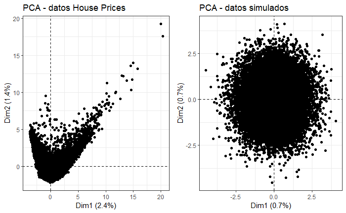

```r
data.simulated.raw <- purrr::map_df(dataset.clust.raw, .f = function(x){ runif(n = length(x), min = min(x),
max = max(x)) })
dataset.scaled.raw <- scale(dataset.clust.raw)
data.simulated.scaled.raw <- scale(data.simulated.raw)
pca_data_credit <- prcomp(dataset.scaled.raw)
pca_data_simulated <- prcomp(data.simulated.scaled.raw)
p1 <- fviz_pca_ind(X = pca_data_credit,
geom = "point", title = "PCA - datos House Prices",
pallete = "jco") +
theme_bw() + theme(legend.position = "bottom")
p2 <- fviz_pca_ind(X = pca_data_simulated, geom = "point",
title = "PCA - datos simulados", pallete = "jco") +
theme_bw() + theme(legend.position = "bottom")
ggarrange(p1, p2, common.legend = TRUE)
```

##### Ancho de Silhouette K=5

Teniendo en cuenta el ancho de Silhouette: - El clúster 1 tiene un ancho de -0.01 es indicativo que la observacion se encuentra en un punto intermedio entre dos clústeres. - El clúster 2 tiene un ancho de -0.07 es indicativo que la observacion se encuentra en un punto intermedio entre dos clústeres. - El clúster 3 tiene un ancho de -0.22 es indicativo que la observacion se encuentra en un punto intermedio entre dos clústeres. - El clúster 4 tiene un ancho de 0.07 es indicativo que la observacion se encuentra en un punto intermedio entre dos clústeres. - El clúster 5 tiene un ancho de 0.54 es indicativo que la observacion fue asignada al clúster correcto.

|  | cluster | size | ave.sil.width |
| --- | --- | --- | --- |
| 1 | 1 | 3941 | -0.01 |
| 2 | 2 | 4525 | -0.07 |
| 3 | 3 | 533 | -0.22 |
| 4 | 4 | 12412 | 0.07 |
| 5 | 5 | 202 | 0.54 |

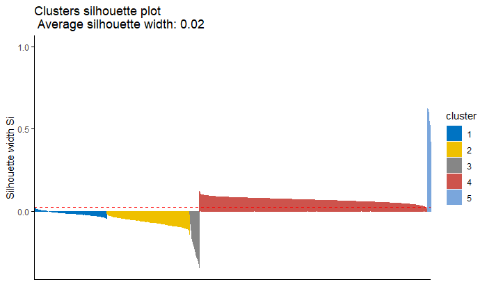

```r
k.means.fit.5 <- eclust(x = dataset.scaled.raw.5, FUNcluster = "kmeans", k = 5, seed = 123,
hc_metric = "euclidean", nstart = 50, graph = FALSE)
fviz_silhouette(sil.obj = k.means.fit.5, print.summary = TRUE, palette = "jco",
ggtheme = theme_classic())
```

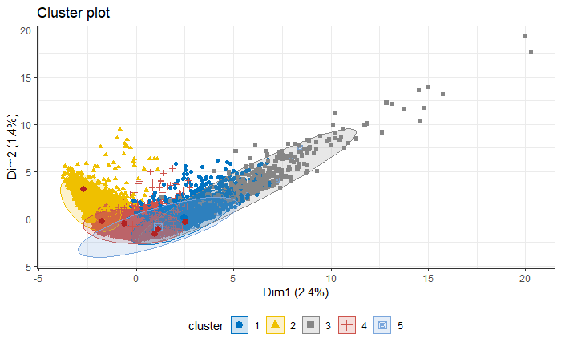

```r
p <- fviz_cluster(object = k.means.fit.5, geom = "point", ellipse.type = "norm",
palette = "jco")
p + geom_point(data = p$data[c(356,327,175,185,29,348),],
colour = "firebrick", size = 2.5) + theme_bw() + theme(legend.position = "bottom")
```

## Dataset Limpio

```r
dataset_clustering_clean <- dataset.selection.clean
summary(dataset_clustering_clean)
```

```
     price           bedrooms      sqft_living      yr_built        grade
 Min.   : 81000   Min.   :2.000   Min.   : 520   Min.   :1900   Min.   : 4.000
 1st Qu.:294000   1st Qu.:3.000   1st Qu.:1300   1st Qu.:1948   1st Qu.: 7.000
 Median :397000   Median :3.000   Median :1660   Median :1968   Median : 7.000
 Mean   :419400   Mean   :3.175   Mean   :1697   Mean   :1968   Mean   : 7.256
 3rd Qu.:528000   3rd Qu.:4.000   3rd Qu.:2080   3rd Qu.:1994   3rd Qu.: 8.000
 Max.   :850000   Max.   :5.000   Max.   :3200   Max.   :2015   Max.   :11.000
      view          sqft_lot     sqft_living15
 Min.   :0.000   Min.   :  520   Min.   : 620
 1st Qu.:0.000   1st Qu.: 4400   1st Qu.:1390
 Median :0.000   Median : 6600   Median :1650
 Mean   :0.106   Mean   : 6374   Mean   :1704
 3rd Qu.:0.000   3rd Qu.: 8400   3rd Qu.:1990
 Max.   :4.000   Max.   :12000   Max.   :2850
```

```r
dataset_clustering_clean$bedrooms<-as.factor(dataset.selection.clean$bedrooms)
dataset_clustering_clean$yr_built<-as.factor(dataset.selection.clean$yr_built)
dataset_clustering_clean$grade<-as.factor(dataset.selection.clean$grade)
dataset_clustering_clean$view<-as.factor(dataset.selection.clean$view)
```

```r
str(dataset_clustering_clean)
```

```
'data.frame':   13865 obs. of  8 variables:
 $ price        : num  221900 538000 180000 604000 510000 ...
 $ bedrooms     : Factor w/ 4 levels "2","3","4","5": 2 2 1 3 2 2 2 2 2 1 ...
 $ sqft_living  : int  1180 2570 770 1960 1680 1715 1060 1780 1890 1160 ...
 $ yr_built     : Factor w/ 116 levels "1900","1901",..: 56 52 34 66 88 96 64 61 104 43 ...
 $ grade        : Factor w/ 8 levels "4","5","6","7",..: 4 4 3 4 5 4 4 4 4 4 ...
 $ view         : Factor w/ 5 levels "0","1","2","3",..: 1 1 1 1 1 1 1 1 1 1 ...
 $ sqft_lot     : int  5650 7242 10000 5000 8080 6819 9711 7470 6560 6000 ...
 $ sqft_living15: int  1340 1690 2720 1360 1800 2238 1650 1780 2390 1330 ...
```

### Convertir variables categóricas

Transformamos las variables categóricas como: - yr_built. - grade. - view. - bedrooms.

```r
dataset.clust.clean <- dataset_clustering_clean
dataset.clust.clean <- dummy_cols(dataset.clust.clean, c("bedrooms","yr_built","grade",
                                 "view"),
remove_first_dummy = TRUE)
dataset.clust.clean[,c("bedrooms","yr_built","grade",
                                 "view")] <- NULL
```

### K-Means

#### K=5

```r
dataset.scaled.clean.5 <- scale(dataset.clust.clean)
```

```r
k.means.fit.clean.5 <- kmeans(dataset.scaled.clean.5, centers = 5, nstart = 25)
print(k.means.fit.clean.5)
```

```
K-means clustering with 5 clusters of sizes 7223, 128, 1793, 4690, 31

Cluster means:
        price sqft_living    sqft_lot sqft_living15  bedrooms_3  bedrooms_4
1 -0.16147957  -0.1432382  0.10589145    -0.1998157  0.06894736 -0.04439377
2 -0.09399175   0.6064611 -0.07988129     0.7241567  0.04540633  0.29490639
3 -0.79400181  -1.0509327  0.08399923    -0.8828239 -0.20199889 -0.34045793
4  0.55508003   0.6109806 -0.19205950     0.6297005 -0.02710406  0.19343764
5 -0.04136085  -0.7804494 -0.14453802    -0.6392043 -0.46828191 -0.44752540
   bedrooms_5 yr_built_1901 yr_built_1902 yr_built_1903 yr_built_1904 yr_built_1905
1  0.04471663  -0.005005098   0.001874966  0.0005397381  -0.004756418  -0.005945955
2 -0.05786017  -0.041639569  -0.039863972 -0.0524218272  -0.052421827  -0.057060631
3 -0.11568932   0.052274922   0.002171771  0.0862574261   0.118260331   0.070409078
4 -0.02376157  -0.010864909  -0.002366416 -0.0320304953  -0.036108762  -0.015825843
5  0.10614753  -0.041639569  -0.039863972 -0.0524218272  -0.052421827  -0.057060631
```

[output cut: 182 more lines]

```r
k.means.fit.clean.5$size
```

```
[1] 7223  128 1793 4690   31
```

```r
k.means.fit.clean.5$cluster
```

[output not shown]

```r
k.means.fit.clean.5$centers
```

```
        price sqft_living    sqft_lot sqft_living15  bedrooms_3  bedrooms_4
1 -0.16147957  -0.1432382  0.10589145    -0.1998157  0.06894736 -0.04439377
2 -0.09399175   0.6064611 -0.07988129     0.7241567  0.04540633  0.29490639
3 -0.79400181  -1.0509327  0.08399923    -0.8828239 -0.20199889 -0.34045793
4  0.55508003   0.6109806 -0.19205950     0.6297005 -0.02710406  0.19343764
5 -0.04136085  -0.7804494 -0.14453802    -0.6392043 -0.46828191 -0.44752540
   bedrooms_5 yr_built_1901 yr_built_1902 yr_built_1903 yr_built_1904 yr_built_1905
1  0.04471663  -0.005005098   0.001874966  0.0005397381  -0.004756418  -0.005945955
2 -0.05786017  -0.041639569  -0.039863972 -0.0524218272  -0.052421827  -0.057060631
3 -0.11568932   0.052274922   0.002171771  0.0862574261   0.118260331   0.070409078
4 -0.02376157  -0.010864909  -0.002366416 -0.0320304953  -0.036108762  -0.015825843
5  0.10614753  -0.041639569  -0.039863972 -0.0524218272  -0.052421827  -0.057060631
  yr_built_1906 yr_built_1907 yr_built_1908 yr_built_1909 yr_built_1910
1    0.01781315  -0.011798417   0.009515695    0.02135967   0.004568303
2   -0.07071838  -0.058938364  -0.068095599   -0.07174116  -0.080374406
```

[output cut: 141 more lines]

#### Crear Dataset con clusters

Mediante la instrucción cbind() agregamos al dataset el vector con el numero de cluster al que pertenece cada punto.

```r
dataset_cluster_clean_5 <- dataset.clust.clean

dataset_cluster_clean_5 <- cbind(dataset_cluster_clean_5,
                               cluster = k.means.fit.clean.5$cluster)
```

#### Creacion de dataset de cada cluster

##### Cluster 1

```r
cluster_1_clean_kmean5 <- dataset_cluster_clean_5
cluster_1_clean_kmean5 <- filter(cluster_1_clean_kmean5,cluster==1)
cluster_1_clean_kmean5$cluster=NULL
```

##### Sumario Cluster 1

Gracias al sumario podemos conocer que las observaciones que se agruparon en este clúster tienen las siguientes características: - Tienen un precio promedio de U$D 393603. - Tienen un tamaño promedio de 1623 sqft. - Tienen habitaciones con 3,4 o 5 sqft. - Fueron construidas entre 1901 y 2015. - Tienen grados 7 y 8. - Fueron vistas entre 1 y 4 veces. - Tienen un tamaño promedio de lote de 6662 sqft.

```r
sumario_cluster_clean_1_kmean5 <- summary(cluster_1_clean_kmean5)
sumario_cluster_clean_1_kmean5
```

```
     price         sqft_living      sqft_lot     sqft_living15    bedrooms_3
 Min.   : 90000   Min.   : 680   Min.   :  520   Min.   : 690   Min.   :0.0000
 1st Qu.:280000   1st Qu.:1290   1st Qu.: 4800   1st Qu.:1390   1st Qu.:0.0000
 Median :370000   Median :1590   Median : 7050   Median :1580   Median :1.0000
 Mean   :393603   Mean   :1623   Mean   : 6662   Mean   :1620   Mean   :0.5586
 3rd Qu.:480000   3rd Qu.:1910   3rd Qu.: 8499   3rd Qu.:1820   3rd Qu.:1.0000
 Max.   :850000   Max.   :3170   Max.   :12000   Max.   :2850   Max.   :1.0000
   bedrooms_4       bedrooms_5      yr_built_1901      yr_built_1902
 Min.   :0.0000   Min.   :0.00000   Min.   :0.000000   Min.   :0.000000
 1st Qu.:0.0000   1st Qu.:0.00000   1st Qu.:0.000000   1st Qu.:0.000000
 Median :0.0000   Median :0.00000   Median :0.000000   Median :0.000000
 Mean   :0.2416   Mean   :0.05206   Mean   :0.001523   Mean   :0.001661
 3rd Qu.:0.0000   3rd Qu.:0.00000   3rd Qu.:0.000000   3rd Qu.:0.000000
 Max.   :1.0000   Max.   :1.00000   Max.   :1.000000   Max.   :1.000000
 yr_built_1903      yr_built_1904      yr_built_1905      yr_built_1906
 Min.   :0.000000   Min.   :0.000000   Min.   :0.000000   Min.   :0.00000
 1st Qu.:0.000000   1st Qu.:0.000000   1st Qu.:0.000000   1st Qu.:0.00000
 Median :0.000000   Median :0.000000   Median :0.000000   Median :0.00000
 Mean   :0.002769   Mean   :0.002492   Mean   :0.002907   Mean   :0.00623
 3rd Qu.:0.000000   3rd Qu.:0.000000   3rd Qu.:0.000000   3rd Qu.:0.00000
 Max.   :1.000000   Max.   :1.000000   Max.   :1.000000   Max.   :1.00000
 yr_built_1907      yr_built_1908      yr_built_1909      yr_built_1910
 Min.   :0.000000   Min.   :0.000000   Min.   :0.000000   Min.   :0.000000
 1st Qu.:0.000000   1st Qu.:0.000000   1st Qu.:0.000000   1st Qu.:0.000000
 Median :0.000000   Median :0.000000   Median :0.000000   Median :0.000000
 Mean   :0.002769   Mean   :0.005261   Mean   :0.006645   Mean   :0.006784
 3rd Qu.:0.000000   3rd Qu.:0.000000   3rd Qu.:0.000000   3rd Qu.:0.000000
 Max.   :1.000000   Max.   :1.000000   Max.   :1.000000   Max.   :1.000000
 yr_built_1911      yr_built_1912      yr_built_1913      yr_built_1914
 Min.   :0.000000   Min.   :0.000000   Min.   :0.000000   Min.   :0.000000
 1st Qu.:0.000000   1st Qu.:0.000000   1st Qu.:0.000000   1st Qu.:0.000000
 Median :0.000000   Median :0.000000   Median :0.000000   Median :0.000000
 Mean   :0.004015   Mean   :0.004292   Mean   :0.003184   Mean   :0.002354
 3rd Qu.:0.000000   3rd Qu.:0.000000   3rd Qu.:0.000000   3rd Qu.:0.000000
 Max.   :1.000000   Max.   :1.000000   Max.   :1.000000   Max.   :1.000000
 yr_built_1915    yr_built_1916      yr_built_1917      yr_built_1918
 Min.   :0.0000   Min.   :0.000000   Min.   :0.000000   Min.   :0.000000
 1st Qu.:0.0000   1st Qu.:0.000000   1st Qu.:0.000000   1st Qu.:0.000000
 Median :0.0000   Median :0.000000   Median :0.000000   Median :0.000000
 Mean   :0.0036   Mean   :0.005399   Mean   :0.002215   Mean   :0.005815
```

[output cut: 176 more lines]

```
 Max.   :0     Max.   :0   Max.   :0   Max.   :1.0000   Max.   :1.0000000
    grade_9     grade_10    grade_11     view_1             view_2
 Min.   :0   Min.   :0   Min.   :0   Min.   :0.000000   Min.   :0.00000
 1st Qu.:0   1st Qu.:0   1st Qu.:0   1st Qu.:0.000000   1st Qu.:0.00000
 Median :0   Median :0   Median :0   Median :0.000000   Median :0.00000
 Mean   :0   Mean   :0   Mean   :0   Mean   :0.008445   Mean   :0.02298
 3rd Qu.:0   3rd Qu.:0   3rd Qu.:0   3rd Qu.:0.000000   3rd Qu.:0.00000
 Max.   :0   Max.   :0   Max.   :0   Max.   :1.000000   Max.   :1.00000
     view_3             view_4
 Min.   :0.000000   Min.   :0.0000
 1st Qu.:0.000000   1st Qu.:0.0000
 Median :0.000000   Median :0.0000
 Mean   :0.006922   Mean   :0.0018
 3rd Qu.:0.000000   3rd Qu.:0.0000
 Max.   :1.000000   Max.   :1.0000
```

##### Cluster 2

```r
cluster_2_clean_kmean5 <- dataset_cluster_clean_5
cluster_2_clean_kmean5 <- filter(cluster_2_clean_kmean5,cluster==2)
cluster_2_clean_kmean5$cluster=NULL
```

##### Sumario Cluster 2

```r
sumario_cluster_clean_2_kmean5 <- summary(cluster_2_clean_kmean5)
sumario_cluster_clean_2_kmean5
```

```
     price         sqft_living      sqft_lot     sqft_living15    bedrooms_3
 Min.   :168000   Min.   : 900   Min.   : 1022   Min.   : 900   Min.   :0.0000
 1st Qu.:299750   1st Qu.:1685   1st Qu.: 4200   1st Qu.:1598   1st Qu.:0.0000
 Median :359225   Median :2035   Median : 6276   Median :2050   Median :1.0000
 Mean   :404384   Mean   :2013   Mean   : 6157   Mean   :2010   Mean   :0.5469
 3rd Qu.:500000   3rd Qu.:2392   3rd Qu.: 7959   3rd Qu.:2420   3rd Qu.:1.0000
 Max.   :812000   Max.   :3030   Max.   :12000   Max.   :2780   Max.   :1.0000
   bedrooms_4       bedrooms_5      yr_built_1901 yr_built_1902 yr_built_1903
 Min.   :0.0000   Min.   :0.00000   Min.   :0     Min.   :0     Min.   :0
 1st Qu.:0.0000   1st Qu.:0.00000   1st Qu.:0     1st Qu.:0     1st Qu.:0
 Median :0.0000   Median :0.00000   Median :0     Median :0     Median :0
 Mean   :0.3906   Mean   :0.03125   Mean   :0     Mean   :0     Mean   :0
 3rd Qu.:1.0000   3rd Qu.:0.00000   3rd Qu.:0     3rd Qu.:0     3rd Qu.:0
 Max.   :1.0000   Max.   :1.00000   Max.   :0     Max.   :0     Max.   :0
 yr_built_1904 yr_built_1905 yr_built_1906 yr_built_1907 yr_built_1908
 Min.   :0     Min.   :0     Min.   :0     Min.   :0     Min.   :0
 1st Qu.:0     1st Qu.:0     1st Qu.:0     1st Qu.:0     1st Qu.:0
 Median :0     Median :0     Median :0     Median :0     Median :0
 Mean   :0     Mean   :0     Mean   :0     Mean   :0     Mean   :0
 3rd Qu.:0     3rd Qu.:0     3rd Qu.:0     3rd Qu.:0     3rd Qu.:0
 Max.   :0     Max.   :0     Max.   :0     Max.   :0     Max.   :0
 yr_built_1909 yr_built_1910 yr_built_1911 yr_built_1912 yr_built_1913
 Min.   :0     Min.   :0     Min.   :0     Min.   :0     Min.   :0
 1st Qu.:0     1st Qu.:0     1st Qu.:0     1st Qu.:0     1st Qu.:0
 Median :0     Median :0     Median :0     Median :0     Median :0
 Mean   :0     Mean   :0     Mean   :0     Mean   :0     Mean   :0
 3rd Qu.:0     3rd Qu.:0     3rd Qu.:0     3rd Qu.:0     3rd Qu.:0
 Max.   :0     Max.   :0     Max.   :0     Max.   :0     Max.   :0
 yr_built_1914 yr_built_1915 yr_built_1916 yr_built_1917 yr_built_1918
 Min.   :0     Min.   :0     Min.   :0     Min.   :0     Min.   :0
 1st Qu.:0     1st Qu.:0     1st Qu.:0     1st Qu.:0     1st Qu.:0
 Median :0     Median :0     Median :0     Median :0     Median :0
 Mean   :0     Mean   :0     Mean   :0     Mean   :0     Mean   :0
 3rd Qu.:0     3rd Qu.:0     3rd Qu.:0     3rd Qu.:0     3rd Qu.:0
 Max.   :0     Max.   :0     Max.   :0     Max.   :0     Max.   :0
 yr_built_1919 yr_built_1920 yr_built_1921 yr_built_1922 yr_built_1923
 Min.   :0     Min.   :0     Min.   :0     Min.   :0     Min.   :0
 1st Qu.:0     1st Qu.:0     1st Qu.:0     1st Qu.:0     1st Qu.:0
 Median :0     Median :0     Median :0     Median :0     Median :0
 Mean   :0     Mean   :0     Mean   :0     Mean   :0     Mean   :0
```

[output cut: 134 more lines]

```
 Max.   :0     Max.   :0     Max.   :0   Max.   :1.000000   Max.   :1.0000
    grade_8          grade_9         grade_10           grade_11     view_1
 Min.   :0.0000   Min.   :0.000   Min.   :0.000000   Min.   :0   Min.   :0.000000
 1st Qu.:0.0000   1st Qu.:0.000   1st Qu.:0.000000   1st Qu.:0   1st Qu.:0.000000
 Median :0.0000   Median :0.000   Median :0.000000   Median :0   Median :0.000000
 Mean   :0.4922   Mean   :0.125   Mean   :0.007812   Mean   :0   Mean   :0.007812
 3rd Qu.:1.0000   3rd Qu.:0.000   3rd Qu.:0.000000   3rd Qu.:0   3rd Qu.:0.000000
 Max.   :1.0000   Max.   :1.000   Max.   :1.000000   Max.   :0   Max.   :1.000000
     view_2            view_3             view_4
 Min.   :0.00000   Min.   :0.000000   Min.   :0
 1st Qu.:0.00000   1st Qu.:0.000000   1st Qu.:0
 Median :0.00000   Median :0.000000   Median :0
 Mean   :0.03125   Mean   :0.007812   Mean   :0
 3rd Qu.:0.00000   3rd Qu.:0.000000   3rd Qu.:0
 Max.   :1.00000   Max.   :1.000000   Max.   :0
```

##### Cluster 3

```r
cluster_3_clean_kmean5 <- dataset_cluster_clean_5
cluster_3_clean_kmean5 <- filter(cluster_3_clean_kmean5,cluster==3)
cluster_3_clean_kmean5$cluster=NULL
```

##### Sumario Cluster 3

```r
sumario_cluster_clean_3_kmean5 <- summary(cluster_3_clean_kmean5)
sumario_cluster_clean_3_kmean5
```

```
     price         sqft_living      sqft_lot     sqft_living15    bedrooms_3
 Min.   : 81000   Min.   : 520   Min.   :  835   Min.   : 620   Min.   :0.0000
 1st Qu.:210000   1st Qu.: 880   1st Qu.: 5001   1st Qu.:1100   1st Qu.:0.0000
 Median :267800   Median :1070   Median : 6450   Median :1280   Median :0.0000
 Mean   :292552   Mean   :1151   Mean   : 6603   Mean   :1331   Mean   :0.4233
 3rd Qu.:359000   3rd Qu.:1350   3rd Qu.: 8125   3rd Qu.:1500   3rd Qu.:1.0000
 Max.   :795000   Max.   :3160   Max.   :12000   Max.   :2830   Max.   :1.0000
   bedrooms_4       bedrooms_5      yr_built_1901      yr_built_1902
 Min.   :0.0000   Min.   :0.00000   Min.   :0.000000   Min.   :0.000000
 1st Qu.:0.0000   1st Qu.:0.00000   1st Qu.:0.000000   1st Qu.:0.000000
 Median :0.0000   Median :0.00000   Median :0.000000   Median :0.000000
 Mean   :0.1115   Mean   :0.01952   Mean   :0.003904   Mean   :0.001673
 3rd Qu.:0.0000   3rd Qu.:0.00000   3rd Qu.:0.000000   3rd Qu.:0.000000
 Max.   :1.0000   Max.   :1.00000   Max.   :1.000000   Max.   :1.000000
 yr_built_1903     yr_built_1904      yr_built_1905     yr_built_1906
 Min.   :0.00000   Min.   :0.000000   Min.   :0.00000   Min.   :0.000000
 1st Qu.:0.00000   1st Qu.:0.000000   1st Qu.:0.00000   1st Qu.:0.000000
 Median :0.00000   Median :0.000000   Median :0.00000   Median :0.000000
 Mean   :0.00725   Mean   :0.008924   Mean   :0.00725   Mean   :0.008366
 3rd Qu.:0.00000   3rd Qu.:0.000000   3rd Qu.:0.00000   3rd Qu.:0.000000
 Max.   :1.00000   Max.   :1.000000   Max.   :1.00000   Max.   :1.000000
 yr_built_1907      yr_built_1908      yr_built_1909     yr_built_1910
 Min.   :0.000000   Min.   :0.000000   Min.   :0.00000   Min.   :0.00000
 1st Qu.:0.000000   1st Qu.:0.000000   1st Qu.:0.00000   1st Qu.:0.00000
 Median :0.000000   Median :0.000000   Median :0.00000   Median :0.00000
 Mean   :0.007808   Mean   :0.008924   Mean   :0.00725   Mean   :0.01617
 3rd Qu.:0.000000   3rd Qu.:0.000000   3rd Qu.:0.00000   3rd Qu.:0.00000
 Max.   :1.000000   Max.   :1.000000   Max.   :1.00000   Max.   :1.00000
 yr_built_1911      yr_built_1912      yr_built_1913      yr_built_1914
 Min.   :0.000000   Min.   :0.000000   Min.   :0.000000   Min.   :0.000000
 1st Qu.:0.000000   1st Qu.:0.000000   1st Qu.:0.000000   1st Qu.:0.000000
 Median :0.000000   Median :0.000000   Median :0.000000   Median :0.000000
 Mean   :0.008366   Mean   :0.008366   Mean   :0.006135   Mean   :0.007808
 3rd Qu.:0.000000   3rd Qu.:0.000000   3rd Qu.:0.000000   3rd Qu.:0.000000
 Max.   :1.000000   Max.   :1.000000   Max.   :1.000000   Max.   :1.000000
 yr_built_1915      yr_built_1916     yr_built_1917     yr_built_1918
 Min.   :0.000000   Min.   :0.00000   Min.   :0.00000   Min.   :0.00000
 1st Qu.:0.000000   1st Qu.:0.00000   1st Qu.:0.00000   1st Qu.:0.00000
 Median :0.000000   Median :0.00000   Median :0.00000   Median :0.00000
 Mean   :0.007808   Mean   :0.01115   Mean   :0.01115   Mean   :0.02342
```

[output cut: 169 more lines]

```
 Max.   :0     Max.   :1.00000   Max.   :1.0000   Max.   :1.0000000   Max.   :0
    grade_9     grade_10    grade_11     view_1             view_2
 Min.   :0   Min.   :0   Min.   :0   Min.   :0.000000   Min.   :0.00000
 1st Qu.:0   1st Qu.:0   1st Qu.:0   1st Qu.:0.000000   1st Qu.:0.00000
 Median :0   Median :0   Median :0   Median :0.000000   Median :0.00000
 Mean   :0   Mean   :0   Mean   :0   Mean   :0.008366   Mean   :0.01785
 3rd Qu.:0   3rd Qu.:0   3rd Qu.:0   3rd Qu.:0.000000   3rd Qu.:0.00000
 Max.   :0   Max.   :0   Max.   :0   Max.   :1.000000   Max.   :1.00000
     view_3             view_4
 Min.   :0.000000   Min.   :0.000000
 1st Qu.:0.000000   1st Qu.:0.000000
 Median :0.000000   Median :0.000000
 Mean   :0.002789   Mean   :0.001673
 3rd Qu.:0.000000   3rd Qu.:0.000000
 Max.   :1.000000   Max.   :1.000000
```

##### Cluster 4

```r
cluster_4_clean_kmean5 <- dataset_cluster_clean_5
cluster_4_clean_kmean5 <- filter(cluster_4_clean_kmean5,cluster==4)
cluster_4_clean_kmean5$cluster=NULL
```

##### Sumario Cluster 4

Gracias al sumario podemos conocer que las observaciones que se agruparon en este clúster tienen las siguientes características: - Tienen un precio promedio de U$D 508079. - Tienen un tamaño promedio de 2015 sqft. - Tienen un tamaño de lote promedio de 5852 sqft. - Tienen habitaciones con 3,4 o 5 sqft. - Tienen grados de 7 a 11. - Fueron construidas entre 1901 y 2015.

```r
sumario_cluster_clean_4_kmean5 <- summary(cluster_4_clean_kmean5)
sumario_cluster_clean_4_kmean5
```

```
     price         sqft_living      sqft_lot     sqft_living15    bedrooms_3
 Min.   :140000   Min.   : 750   Min.   :  600   Min.   : 700   Min.   :0.0000
 1st Qu.:379900   1st Qu.:1670   1st Qu.: 3498   1st Qu.:1650   1st Qu.:0.0000
 Median :500000   Median :2040   Median : 5956   Median :1990   Median :1.0000
 Mean   :508079   Mean   :2015   Mean   : 5852   Mean   :1970   Mean   :0.5107
 3rd Qu.:623000   3rd Qu.:2370   3rd Qu.: 8250   3rd Qu.:2290   3rd Qu.:1.0000
 Max.   :850000   Max.   :3200   Max.   :12000   Max.   :2850   Max.   :1.0000
   bedrooms_4       bedrooms_5      yr_built_1901      yr_built_1902
 Min.   :0.0000   Min.   :0.00000   Min.   :0.000000   Min.   :0.000000
 1st Qu.:0.0000   1st Qu.:0.00000   1st Qu.:0.000000   1st Qu.:0.000000
 Median :0.0000   Median :0.00000   Median :0.000000   Median :0.000000
 Mean   :0.3461   Mean   :0.03817   Mean   :0.001279   Mean   :0.001492
 3rd Qu.:1.0000   3rd Qu.:0.00000   3rd Qu.:0.000000   3rd Qu.:0.000000
 Max.   :1.0000   Max.   :1.00000   Max.   :1.000000   Max.   :1.000000
 yr_built_1903      yr_built_1904       yr_built_1905      yr_built_1906
 Min.   :0.000000   Min.   :0.0000000   Min.   :0.000000   Min.   :0.000000
 1st Qu.:0.000000   1st Qu.:0.0000000   1st Qu.:0.000000   1st Qu.:0.000000
 Median :0.000000   Median :0.0000000   Median :0.000000   Median :0.000000
 Mean   :0.001066   Mean   :0.0008529   Mean   :0.002345   Mean   :0.001919
 3rd Qu.:0.000000   3rd Qu.:0.0000000   3rd Qu.:0.000000   3rd Qu.:0.000000
 Max.   :1.000000   Max.   :1.0000000   Max.   :1.000000   Max.   :1.000000
 yr_built_1907      yr_built_1908      yr_built_1909      yr_built_1910
 Min.   :0.000000   Min.   :0.000000   Min.   :0.000000   Min.   :0.000000
 1st Qu.:0.000000   1st Qu.:0.000000   1st Qu.:0.000000   1st Qu.:0.000000
 Median :0.000000   Median :0.000000   Median :0.000000   Median :0.000000
 Mean   :0.002985   Mean   :0.002132   Mean   :0.002132   Mean   :0.002345
 3rd Qu.:0.000000   3rd Qu.:0.000000   3rd Qu.:0.000000   3rd Qu.:0.000000
 Max.   :1.000000   Max.   :1.000000   Max.   :1.000000   Max.   :1.000000
 yr_built_1911      yr_built_1912      yr_built_1913      yr_built_1914
 Min.   :0.000000   Min.   :0.000000   Min.   :0.000000   Min.   :0.000000
 1st Qu.:0.000000   1st Qu.:0.000000   1st Qu.:0.000000   1st Qu.:0.000000
 Median :0.000000   Median :0.000000   Median :0.000000   Median :0.000000
 Mean   :0.001919   Mean   :0.001919   Mean   :0.001279   Mean   :0.001706
 3rd Qu.:0.000000   3rd Qu.:0.000000   3rd Qu.:0.000000   3rd Qu.:0.000000
 Max.   :1.000000   Max.   :1.000000   Max.   :1.000000   Max.   :1.000000
 yr_built_1915      yr_built_1916      yr_built_1917      yr_built_1918
 Min.   :0.000000   Min.   :0.000000   Min.   :0.000000   Min.   :0.000000
 1st Qu.:0.000000   1st Qu.:0.000000   1st Qu.:0.000000   1st Qu.:0.000000
 Median :0.000000   Median :0.000000   Median :0.000000   Median :0.000000
 Mean   :0.001279   Mean   :0.001066   Mean   :0.001279   Mean   :0.001919
```

[output cut: 176 more lines]

```
 Max.   :1.000000   Max.   :0   Max.   :0   Max.   :1.000000   Max.   :1.0000
    grade_9          grade_10          grade_11             view_1
 Min.   :0.0000   Min.   :0.00000   Min.   :0.0000000   Min.   :0.0000
 1st Qu.:0.0000   1st Qu.:0.00000   1st Qu.:0.0000000   1st Qu.:0.0000
 Median :0.0000   Median :0.00000   Median :0.0000000   Median :0.0000
 Mean   :0.1373   Mean   :0.01194   Mean   :0.0002132   Mean   :0.0145
 3rd Qu.:0.0000   3rd Qu.:0.00000   3rd Qu.:0.0000000   3rd Qu.:0.0000
 Max.   :1.0000   Max.   :1.00000   Max.   :1.0000000   Max.   :1.0000
     view_2            view_3            view_4
 Min.   :0.00000   Min.   :0.00000   Min.   :0.000000
 1st Qu.:0.00000   1st Qu.:0.00000   1st Qu.:0.000000
 Median :0.00000   Median :0.00000   Median :0.000000
 Mean   :0.04286   Mean   :0.01727   Mean   :0.002132
 3rd Qu.:0.00000   3rd Qu.:0.00000   3rd Qu.:0.000000
 Max.   :1.00000   Max.   :1.00000   Max.   :1.000000
```

##### Cluster 5

```r
cluster_5_clean_kmean5 <- dataset_cluster_clean_5
cluster_5_clean_kmean5 <- filter(cluster_5_clean_kmean5,cluster==5)
cluster_5_clean_kmean5$cluster=NULL
```

##### Sumario Cluster 5

```r
sumario_cluster_clean_5_kmean5 <- summary(cluster_5_clean_kmean5)
sumario_cluster_clean_5_kmean5
```

[output not shown]

```r
library("factoextra")
library("ggpubr")
data.simulated.clean <- purrr::map_df(dataset.clust.clean, .f = function(x){ runif(n = length(x), min = min(x),
max = max(x)) })
dataset.scaled.clean <- scale(dataset.clust.clean)
data.simulated.scaled.clean <- scale(data.simulated.clean)
pca_data_credit <- prcomp(dataset.scaled.clean)
pca_data_simulated <- prcomp(data.simulated.scaled.clean)
p1 <- fviz_pca_ind(X = pca_data_credit,
geom = "point", title = "PCA - datos House Prices",
pallete = "jco") +
theme_bw() + theme(legend.position = "bottom")
p2 <- fviz_pca_ind(X = pca_data_simulated, geom = "point",
title = "PCA - datos simulados", pallete = "jco") +
theme_bw() + theme(legend.position = "bottom")
ggarrange(p1, p2, common.legend = TRUE)
```

[output not shown]

##### Ancho de Silhouette K=5

```r
k.means.fit.5 <- eclust(x = dataset.scaled.clean.5, FUNcluster = "kmeans", k = 5, seed = 123,
hc_metric = "euclidean", nstart = 50, graph = FALSE)
fviz_silhouette(sil.obj = k.means.fit.5, print.summary = TRUE, palette = "jco",
ggtheme = theme_classic())

p <- fviz_cluster(object = k.means.fit.5, geom = "point", ellipse.type = "norm",
palette = "jco")
p + geom_point(data = p$data[c(356,327,175,185,29,348),],
colour = "firebrick", size = 2.5) + theme_bw() + theme(legend.position = "bottom")
```

[output not shown]

# **Conclusiones**

A lo largo del presente documento realizamos el análisis de datos del dataset de precios de casas en King County, Estados Unidos con el objetivo de realizar la predicción de precios de las mismas. Primero realizamos el análisis exploratorio de datos de cada feature e identificamos los valores atípicos gracias a los boxplots, los histogramas, los gráficos de torta. Luego realizamos la limpieza de los outliers, lo que llevó a la pérdida del 35% de los datos. Luego de la limpieza, utilizamos técnicas de selección de variables y obtuvimos el menor RMSE con la técnica de Lasso. A partir de ello, decidimos tener en cuenta las variables recomendadas por dicha técnica como ser el precio, las dimensiones de la casa, el terreno, las habitaciones, los baños, si fue vista anteriormente, la calificación por el organismo, si tiene sótano. Dichas variables si se condicen con los aspectos a tener en cuenta para la compra de una casa. Después, aplicamos una regresión lineal que no arrojó buenos resultados(Adjusted R-squared cercano al 45%), se trató de mejorarlo utilizando una regresión polinomial pero no hubo una mejora significativa. Entonces, se decidió aplicar regresión lineal con el dataset crudo, vimos que el modelo si era significativo(Adjusted R-squared cercano al 65%), y además al aplicarle una regresión polinomial si obtuvimos una mejora significativa(Adjusted R-squared cercano al 67%). Por lo que descubrimos que al realizar la limpieza, se recortaron valores importantes para el modelo, es por eso que se obtuvieron mejores resultados con el dataset crudo. Luego se decidió aplicar la técnica de clustering con ambos datasets(crudo y limpio) utilizando el algoritmo K-means, realizamos 5 clústers respectivamente con la caracterización de cada uno de ellos e identificando por cuáles características comunes se agruparon. Para finalizar, gracias al análisis efectuado se puede realizar a partir del dataset crudo un estudio de predicción de precios teniendo en cuenta algunas características como las variables seleccionadas(tamaño de la casa, tamaño del terreno, cantidad de baños, cantidad de habitaciones y la calificación del organismo público(grado)) mediante la aplicación de alguna técnica como por ejemplo, árbol de decisiones.